# Даалгавар 2: Data Scrapping

## Task:

Өөрийн сонгон авсан системээс өгөгдлүүдийг гарган авах data scrapping code бичнэ. Data scrap хийхдээ BeautifulSoup and Google colab ашиглана.

Бүх датаг цуглуулаад өгөгдөлөө tsv өргөтгөлтэй хадгалаад явуулна. Гарган авч буй өгөгдөлд тавигдах гол шаардлага нь дор хаяж 7-н баганатай байхыг шаардана. Үүнд линк болон unique identifier орохгүй. Хэрвээ өгөгдөл нь том хэмжээтэй бол Google drive руу хуулаад линкээ явуулна.

## 1. Сонгон авсан систем: Arxiv

[Arxiv](https://arxiv.org) системээс гараас оноосон түлхүүр үгийн дагуу буцаасан эрдэм шинжилгээний өгүүллэгүүдийн мэдээллийг хуулах. Хуулсан мэдээлэлд дараах орно:

1. Arxiv code
2. Гарчиг
3. Зохиолчид
4. Тойм
5. Хэвлэгдсэн сэтгүүл
6. Илгээсэн огноо
7. Зарлагдсан огноо
8. Сэдвүүд

## 2. Google Scholar

[Google Scholar](https://scholar.google.com/) системээс 1-р алхамд хуулсан бүх зохиолчдын мэдээллийг хуулах. Эдгээр нь:

1. Судалгааны чиглэл
2. Сургууль

## 3. Text clustering and NER extraction

Судалгааны өгүүлэл бүрийн abstract-ийн embedding авч clustering хийх бөгөөд нэр үгийг олно. Ерөнхийдөө бол бэлэн модел ашиглан text-г вектор огторгуйд проекц хийнэ.

## 4. Co-authorship сүлжээ байгуулах

Гараас оноосон түлхүүр үгийн хайлтын илэрцээс олдсон судлаачдын сүлжээг байгуулах. (just for fun)

```python
import os
import re
import pickle
import psutil
import pickle
from tqdm import tqdm
from collections import defaultdict
import threading
from concurrent.futures import ThreadPoolExecutor, as_completed

import numpy as np
import pandas as pd

from transformers import AutoTokenizer, AutoModel, AutoModelForTokenClassification
from transformers import pipeline
from sentence_transformers import SentenceTransformer

from sklearn.cluster import KMeans
from sklearn.decomposition import PCA
from sklearn.metrics import silhouette_score
from sklearn.feature_extraction.text import TfidfVectorizer

import igraph as ig
import networkx as nx
import chart_studio.plotly
from chart_studio.plotly import plot, iplot

import requests
from bs4 import BeautifulSoup

from jellyfish import jaro_winkler_similarity

import seaborn as sns
import plotly.graph_objs as go
import matplotlib.pyplot as plt

import plotly.io as pio
pio.renderers.default = 'notebook'

import warnings
warnings.filterwarnings('ignore')

pool = ThreadPoolExecutor()
default_workers_threads = pool._max_workers

print(f"CPU count: {os.cpu_count()}")
print(f"Memory GB: {psutil.virtual_memory().total >> 30}")
print(f"Default thread workers: {default_workers_threads}")
```

```
CPU count: 16
Memory GB: 31
Default thread workers: 20
```

## 1. Arxiv

```python
num_workers = 12

# Arxiv нэг хуудсанд гарах өгүүллэлийг тоог 200 гэж заасан тул хуудас хооронд 200-р шилжинэ (increment)
start_page = 0
end_page = 4000
increment = 200

# Advanced search дээр хайлтын түлхүүр үгээ оруулна. Энэ тохиолдолд 'audio recognition'
search_term = 'audio+recognition'
base_link = f"https://arxiv.org/search/advanced?advanced=&terms-0-operator=AND&terms-0-term={search_term}&terms-0-field=all&classification-physics_archives=all&classification-include_cross_list=include&date-filter_by=all_dates&date-year=&date-from_date=&date-to_date=&date-date_type=submitted_date&abstracts=show&size=200&order=-announced_date_first"

papers = []

# Хуудас бүрийн мэдээллийг авахад бид олон удаа request үүсгэж байгаа. Иймд нэг удаа үүсгэсэн connection-г олон дахин ашиглах үүднээс
# session тодорхойлно
def scrape_papers(start_num):
    session = requests.Session()

    linkie = f"{base_link}&start={start_num}"

    html_text = session.get(linkie).text
    soup = BeautifulSoup(html_text, 'html.parser')

    papers_sub = soup.find_all('li', class_ = 'arxiv-result')

    papers.extend(papers_sub)

    session.close()
```

```python
with ThreadPoolExecutor(max_workers = num_workers) as executor, tqdm(total = (end_page - start_page),
                                                                     desc = f'Scraping papers from arxiv, [SEARCH TERM]: {search_term}') as pbar:
    futures = [executor.submit(scrape_papers, start_num) for start_num in range(start_page, end_page, increment)]
    for future in as_completed(futures):
        pbar.update(increment)

print(f"Number of papers scraped: {len(papers)}")
```

```
Scraping papers from arxiv, [SEARCH TERM]: audio+recognition: 100%|██████████| 4000/4000 [00:28<00:00, 141.87it/s]
```

```
Number of papers scraped: 4000
```

```python
def punct(full_text):
    temp = [sent.strip() for sent in re.findall("""\s+[^.!?]*[.!?]""", full_text)]
    temp = re.sub('\..', '.', '. '.join(temp))
    temp = re.sub('\s+[a-zA-Z]\.', '', temp)

    return temp

arxiv_code = []
titles = []
authors = []
abstracts = []
journal = []
submitted_dates = []
originally_announced_dates = []

patterns = {
    'submitted to': r'submitted to (.+)',
    'Accepted to': r'Accepted to (.+)',
    'Accepted in': r'Accepted in (.+)',
    'accepted by': r'accepted by (.+)',
    'Journal ref': r'Journal ref: (.+)'
}
```

```python
for paper in tqdm(papers, desc = 'Scraping fields'):
    # Arxiv code
    paper_arxiv_code = paper.find('p', class_ = 'list-title is-inline-block').text.split('\n')[0]

    # Paper Title
    paper_title = paper.find('p', class_ = 'title is-5 mathjax').text.strip()

    # Authors
    paper_authors = paper.find('p', class_ = 'authors')
    paper_authors = ','.join([name.text.strip() for name in paper_authors.find_all('a')])

    # Abstract
    paper_abstract = paper.find('p', class_ = 'abstract mathjax')
    paper_abstract = punct(paper_abstract.find('span', class_ = 'abstract-full has-text-grey-dark mathjax').text)

    # Comment, which includes submitted Journals etc.
    # Аливаа өгүүллэгийн хувьд хэвлэгдсэн сэтгүүлийн мэдээлэл нь цөөн тооны pattern-ийн дагуу бичигдсэн байсан.
    # Иймд энэ хэсэгт pattern бүрийг шалгана.
    paper_comment = paper.find('p', class_='comments is-size-7')
    paper_journal = np.nan
    if paper_comment:
        paper_comment_text = re.sub(r'\s+', ' ', paper_comment.text.strip())
        for keyword, pattern in patterns.items():
            if keyword in paper_comment_text:
                match = re.search(pattern, paper_comment_text)
                if match:
                    paper_journal = match.group(1).strip()
                    break
    # Submission date
    # Сүүлд нь бүх хугацааг харсан. Тэгэхэд хугацаа бүр ижил форматтай байсан.
    # Иймд ганц удаа split ашиглаж илгээсэн огноог гаргах боломжтой байсныг ойлгосон. Гэхдээ анх ялгаатай pattern-тай огноо байх вий хэмээн болгоомжилж
    # бичсэн аргаа үлдээсэн.
    submit_date = paper.find('p', class_ = 'is-size-7').text.split(';')[0]
    submit_date = re.findall('([0-9]{1,2}\s(?:Jan(?:uary)?|Feb(?:ruary)?|Mar(?:ch)?|Apr(?:il)?|May|Jun(?:e)?|Jul(?:y)?|Aug(?:ust)?|Sep(?:tember)?|Oct(?:ober)?|(Nov|Dec)(?:ember)?)\, [0-9]{4})', submit_date)
    submit_date = [sent for sent in submit_date[0] if len(sent)][0]

    originally_announced_date = paper.find('p', class_ = 'is-size-7').text.strip().split('originally announced ')[-1][:-1]

    arxiv_code.append(paper_arxiv_code)
    titles.append(paper_title)
    authors.append(paper_authors)
    abstracts.append(paper_abstract)
    journal.append(paper_journal)
    submitted_dates.append(submit_date)
    originally_announced_dates.append(originally_announced_date)
```

```python
df = pd.DataFrame({'title': titles,
                   'authors': authors,
                   'abstract': abstracts,
                   'Journal': journal,
                   'code': arxiv_code,
                   'submitted_date': submitted_dates,
                   'orginally_announced_date': originally_announced_dates})
df['submitted_date'] = pd.to_datetime(df['submitted_date'])
df['orginally_announced_date'] = pd.to_datetime(df['orginally_announced_date'], errors = 'coerce')

df.head()
```

|  | title | authors | abstract | Journal | code | submitted_date | orginally_announced_date |
| --- | --- | --- | --- | --- | --- | --- | --- |
| 0 | UAVM: Towards Unifying Audio and Visual Models | Yuan Gong,Alexander H. Liu,Andrew Rouditchenko... | Conventional audio-visual models have independ... | NaN | arXiv:2208.00061 | 2023-02-15 | 2022-08-01 |
| 1 | Multiple-hypothesis RNN-T Loss for Unsupervise... | Cong-Thanh Do,Mohan Li,Rama Doddipatla | This paper proposes a new approach to perform ... | Interspeech 2022 | arXiv:2207.14736 | 2022-07-29 | 2022-07-01 |
| 2 | Towards Unconstrained Audio Splicing Detection... | Denise Moussa,Germans Hirsch,Christian Riess | Freely available and easy-to-use audio editing... | NaN | arXiv:2207.14682 | 2023-03-31 | 2022-07-01 |
| 3 | Pronunciation-aware unique character encoding ... | Peng Shen,Xugang Lu,Hisashi Kawai | For Mandarin end-to-end (E2E) automatic speech... | NaN | arXiv:2207.14578 | 2022-07-29 | 2022-07-01 |
| 4 | Learning Phone Recognition from Unpaired Audio... | Da-rong Liu,Po-chun Hsu,Yi-chen Chen,Sung-feng... | ASR has been shown to achieve great performanc... | NaN | arXiv:2207.14568 | 2022-07-29 | 2022-07-01 |

```python
# Өгүүлэл бүрийн хувьд хуулсан arxiv code ашиглан өгүүллийн сэдвүүдийг хуулах
paper_all_subjects = []

def get_subjects(paper_arxiv_code, arxiv_base_link = "https://arxiv.org/abs/"):
    session = requests.Session()

    link = arxiv_base_link + paper_arxiv_code
    response = requests.get(link)

    if response.status_code == 200:
        soup = BeautifulSoup(response.text, 'html.parser')
        subject_tag = soup.find('td', class_='tablecell subjects')
        if subject_tag:
            paper_subjects = subject_tag.text.strip()
        else:
            paper_subjects = np.nan
    else:
        paper_subjects = np.nan

    session.close()

    paper_all_subjects.append(paper_subjects)

"""
with ThreadPoolExecutor(max_workers = num_workers) as executor, tqdm(total = len(arxiv_code),
                                                                     desc = f'Scraping subjects from each paper') as pbar:
    futures = [executor.submit(get_subjects, paper_arxiv_code) for paper_arxiv_code in arxiv_code]
    for future in as_completed(futures):
        pbar.update()
"""
df = pd.read_parquet("arxiv_audio+recognition_search_term.parquet")
df.head()
```

|  | title | authors | abstract | Journal | code | submitted_date | orginally_announced_date | subjects |
| --- | --- | --- | --- | --- | --- | --- | --- | --- |
| 0 | M&M: Multimodal-Multitask Model Integrating Au... | Long Nguyen-Phuoc,Renald Gaboriau,Dimitri Dela... | This paper introduces the M&M model, a novel m... | Proceedings of the 19th International Joint Co... | arXiv:2403.09451 | 2024-03-14 | 2024-03-01 | Computation and Language (cs.CL); Sound (cs.SD... |
| 1 | Unsupervised Modality-Transferable Video Highl... | Tingtian Li,Zixun Sun,Xinyu Xiao | Identifying highlight moments of raw video mat... | None | arXiv:2403.09401 | 2024-03-14 | 2024-03-01 | Sound (cs.SD); Computation and Language (cs.CL... |
| 2 | More than words: Advancements and challenges i... | Anna Kruspe | This paper addresses the challenges and advanc... | None | arXiv:2403.09298 | 2024-03-14 | 2024-03-01 | Audio and Speech Processing (eess.AS); Computa... |
| 3 | SpeechColab Leaderboard: An Open-Source Platfo... | Jiayu Du,Jinpeng Li,Guoguo Chen,Wei-Qiang Zhang | In the wake of the surging tide of deep learni... | None | arXiv:2403.08196 | 2024-03-12 | 2024-03-01 | Audio and Speech Processing (eess.AS); Computa... |
| 4 | Automatic Speech Recognition (ASR) for the Dia... | Taekyung Ahn,Yeonjung Hong,Younggon Im,Do Hyun... | This study presents a model of automatic speec... | None | arXiv:2403.08187 | 2024-03-12 | 2024-03-01 | Computer Vision and Pattern Recognition (cs.CV... |

```python
#df['subjects'] = paper_all_subjects
df.info(memory_usage = 'deep')
```

```
<class 'pandas.core.frame.DataFrame'>
RangeIndex: 4000 entries, 0 to 3999
Data columns (total 8 columns):
 #   Column                    Non-Null Count  Dtype
---  ------                    --------------  -----
 0   title                     4000 non-null   object
 1   authors                   4000 non-null   object
 2   abstract                  4000 non-null   object
 3   Journal                   617 non-null    object
 4   code                      4000 non-null   object
 5   submitted_date            4000 non-null   datetime64[ns]
 6   orginally_announced_date  4000 non-null   datetime64[ns]
 7   subjects                  4000 non-null   object
dtypes: datetime64[ns](2), object(6)
memory usage: 6.8 MB
```

```python
#output_filename = f"arxiv_{search_term}_search_term"
#df.to_parquet(f"{output_filename}.parquet")
#df.to_csv(f"{output_filename}.tsv", sep = "\t")
```

## 2. Google Scholar

```python
# Өгүүлэл бүрийн хувьд хамт ажилласан судлаачдын хүснэгтийг байгуулах.
author_pairs = []

for authors in df['authors']:
    author_list = authors.split(',')
    author_pairs.extend([(author.strip(), other_author.strip()) for i, author in enumerate(author_list) for other_author in author_list[i+1:]])

author_pair_df = pd.DataFrame(author_pairs, columns = ['Author1', 'Author2'])

print(f"Authors network shape: {author_pair_df.shape}")
author_pair_df.head()
```

```
Authors network shape: (59140, 2)
```

|  | Author1 | Author2 |
| --- | --- | --- |
| 0 | Long Nguyen-Phuoc | Renald Gaboriau |
| 1 | Long Nguyen-Phuoc | Dimitri Delacroix |
| 2 | Long Nguyen-Phuoc | Laurent Navarro |
| 3 | Renald Gaboriau | Dimitri Delacroix |
| 4 | Renald Gaboriau | Laurent Navarro |

### Судлаачдын нэрийг зөв олох

Энэ хэсэгт судлаачдын мэдээллийг үнэн зөв хуулахын тулд судлаачдын нэрийг үнэн зөв тааруулах буюу олох шаардлагатай байсан. Иймд google scholar дээрээс судлаачдын нэрийг тааруулахад **Jaro-Winkler Зай** тооцсон ба гараас босго тогтоосон.

Энэ зай нь гараас оноосон $s_1$, $s_2$ тэмдэгт мөрийн хувьд хоорондоо таарсан тэмдэгтийн жинлэсэн давтамжийг тооцдог.

$$sim_j = \begin{cases} 0 & \text{if } m = 0 \\ \frac{1}{3} \left[ \frac{m}{|s_1|} + \frac{m}{|s_2|} + \frac{m-t}{m}\right] & \text{otherwise} \end{cases}$$

энд:

- $|s_i|$ тэмдэгт мөрийн урт
- $m$ хоорондоо таарсан тэмдэгтийн тоо
- $t$ нийт удаа хийгдсэн шилжилтийн тоо

Тодорхойлолт: $s_1$, $s_2$-н 2 тэмдэгтүүд нь хоорондоо ижил байх нөхцөл нь:

1. Ижил тэмдэгт
2. Хоорондоо $\lfloor \frac{\max(|s_1|, |s_2|)}{2} \rfloor$ тэмдэгтээс холгүй зайтай байх

Хоорондоо таарсан тэмдэгтийн жишээ авъя. `FAREMVIEL` болон `FARMVILLE`. **F**, **A**, **R** ижил байрлалд байна. Харин `M`, `V`, `I`, `E`, `L` 3 тэмдэгтийн зайд байна. Иймд нийт 8 тэмдэгт хоорондоо таарч байна.

Шилжилтийн тоо гэдэг нь $s_1$, $s_2$ мөрүүдийн хоорондоо таарч байгаа гэхдээ ялгаатай байрлалд байгаа тэмдэгтүүдийн тоог 2-т хуваасан тоо юм. Дээрх мөрүүдийн хувьд ялгаатай байрлалд байгаа тэмдэгт нь `E`, `L`.

Иймд `FAREMVIEL` болон `FARMVILLE` хоорондох зай (төсөө) нь $\frac{1}{3} (\frac{8}{9} + \frac{8}{9} + \frac{8-1}{8}) = 0.88$

Source: [Jaro–Winkler distance](https://en.wikipedia.org/wiki/Jaro%E2%80%93Winkler_distance)

```python
session = requests.Session()

# Unique нэр бүрийн хувьд google scholar дээрээс уг нэрийг оруулан хайлт хийнэ.
# Хайлтаас илэрсэн нэр бүртэй төсөөг нь тооцно. Гараас оруулсан босгыг хангаж байвал нэг хүн гэж үзнэ.
def return_matching_profile_link(base_link, author, cut_off = 0.6):
    author_search_name = author.replace(' ', '+')
    linkie = f'https://scholar.google.com/citations?hl=en&view_op=search_authors&mauthors={author_search_name}&btnG='

    html_text = session.get(linkie).text
    soup = BeautifulSoup(html_text, 'html.parser')

    profile = soup.find_all('div', class_ = 'gsc_1usr')

    jaro_similarity_scores = []
    hit_names = []
    links = []

    if profile:
        for hit in profile:
            hit = hit.find('h3', class_='gs_ai_name').find('a')
            hit_name = hit.text.strip()
            hit_link = base_link + hit['href']

            # Jaro-Winkler төсөөг тооцох.
            jaro_similarity_score = jaro_winkler_similarity(author, hit_name)

            if jaro_similarity_score >= cut_off:
                jaro_similarity_scores.append(jaro_similarity_score)
                links.append(hit_link)
                hit_names.append(hit_name)

    if len(jaro_similarity_scores):
        # Нэгээс олон нэр босго хангах боломжтой учир тэдгээрээс хамгийн өндөр оноотойг сонгох.
        max_score_ind = np.argmax(jaro_similarity_scores)
        max_score_profile_name = hit_names[max_score_ind]
        profile_link = links[max_score_ind]
    else:
        profile_link = None
        max_score_profile_name = np.nan

    return profile_link, max_score_profile_name
```

```python
# Судлаачийг google scholar-с зөв олсон гэж үзэн холбогдох мэдээллүүдийг хуулах.
def return_author_info(profile_link):
    if profile_link:
        user_html_text = session.get(profile_link).text
        user_soup = BeautifulSoup(user_html_text, 'html.parser')

        institute = user_soup.find('div', class_='gsc_prf_il')
        research_area = user_soup.find('div', {"id": "gsc_prf_int"}, class_='gsc_prf_il')

        if institute:
            institute = institute.text.strip()
        if research_area:
            research_area = [item.text.lower().strip() for item in research_area.find_all('a')]
        elif (not institute) and (not research_area):
            institute = np.nan
            research_area = np.nan
    else:
        institute = np.nan
        research_area = np.nan

    return institute, research_area
```

```python
hit_names = []
author_institute = []
author_research_area = []
author_unique_names = pd.concat([author_pair_df['Author1'], author_pair_df['Author2']]).unique().tolist()

base_link = 'https://scholar.google.com'

"""
def process_author(name):
    profile_link, min_score_profile_name = return_matching_profile_link(base_link, name)
    institute, research_area = return_author_info(profile_link)

    if isinstance(research_area, list):
        research_area = ','.join(research_area)

    hit_names.append(min_score_profile_name)
    author_institute.append(institute)
    author_research_area.append(research_area)

with ThreadPoolExecutor(max_workers = num_workers) as executor:
    future_to_author = {executor.submit(process_author, name): name for name in author_unique_names}

    for future in tqdm(as_completed(future_to_author),
                       total = len(future_to_author), desc = "Processing Authors"):
        author_name = future_to_author[future]
        try:
            future.result()
        except Exception as e:
            print(f"Error processing author {author_name}: {e}")
"""
for name in tqdm(author_unique_names, desc = "Processing Authors"):
    profile_link, min_score_profile_name = return_matching_profile_link(name)
    institue, research_area = return_author_info(profile_link)

    if isinstance(research_area, list):
        research_area = ','.join(research_area)

    hit_names.append(min_score_profile_name)
    author_institute.append(institue)
    author_research_area.append(research_area)
```

Нийт нэрийн тооноос хамааран программ 2-5 цаг ажиллах тохиолдлууд гарч байсан. Иймд судлаачийн мэдээллийг хуулах ажлыг салаалах буюу параллелиар хийхээр шийдсэн.

Edit: Параллелиар хуулалт хийх үед google scholar-руу олон тооны хандалт илгээгдэж байгаа. Үүнийг google bot хэмээн үзэж миний холболтыг хязгаарлаж байгаа тул энэ хэсэгт хуулалтыг нэг нэгээр нь хийхээр босон. Гэсэн хэдий ч миний холболтыг bot хэмээн flag хийсэн нь дуусаагүй тул энэ хэсэг боломжгүй болов.

Гэвч яг энэ кодыг ашиглан би 2 жилийн өмнө судлаач бүрийн мэдээллийг Google Scholar-с авч байсан. Энэхүү датаг би тухайн үед Kaggle дээрээ public тохиргоотой оруулсан.

https://www.kaggle.com/datasets/temuujinerdene/nlpresearchers

```python
# Хуулсан мэдээллүүдээ pickle формат болон хүснэгтээс хадгалах
with open('author_institute.pickle', 'wb') as handle:
    pickle.dump(author_institute, handle, protocol = pickle.HIGHEST_PROTOCOL)
    print("saved to author_institute.pickle")
```

[output not shown]

```python
with open('author_research_area.pickle', 'wb') as handle:
    pickle.dump(author_research_area, handle, protocol = pickle.HIGHEST_PROTOCOL)
    print("saved to author_research_area.pickle")
```

[output not shown]

```python
authors_info = pd.DataFrame({'author': author_unique_names,
                             'hit_name': hit_names,
                             'institute': author_institute,
                             'research_area': author_research_area})
print(f"Authors info df shape: {authors_info.shape}")
authors_info.sample(10)
```

[output not shown]

```python
authors_info.info(memory_usage = 'deep')
```

[output not shown]

```python
output_filename = f"arxiv_{search_term}_search_term_authors_info"
authors_info.to_parquet(f"{output_filename}.parquet")
```

```python
authors_info.to_csv(f"{output_filename}.tsv", sep = '\t')
```

## 3. Text analysis

Хуулсан судалгааны өгүүлэл бүрийн сэдвүүдийн тооны статистик.

```python
def explode_subjects(x):
    pattern = r'([^();]+) \(([\w.]+)\)'
    matches = re.findall(pattern, x)

    subject_list = []
    key_list = []

    for subject, key in matches:
        subject_list.append(subject.strip())
        key_list.append(key.strip())

    return subject_list, key_list
```

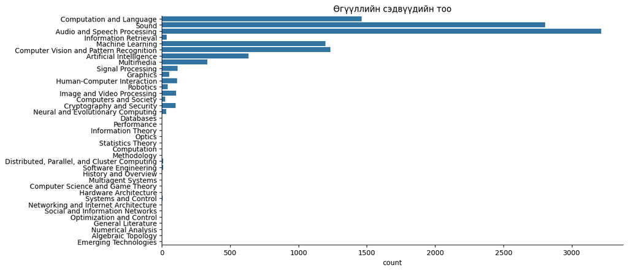

```python
all_subjects = []
all_keys = []

for val in tqdm(df['subjects'].values):
    subject_list, key_list = explode_subjects(val)

    all_subjects.extend(subject_list)
    all_keys.extend(key_list)

fig, ax = plt.subplots(num = 1, clear = True, figsize = (12, 6))
sns.countplot(all_subjects, stat = 'count', ax = ax)
ax.spines[['top', 'right']].set_visible(False)

ax.set_title("Өгүүллийн сэдвүүдийн тоо");
```

### 3.1 Text Embedding

```python
abstracts = df['abstract'].tolist()

# Load the pre-trained model and tokenizer
model_name = "allenai/scibert_scivocab_uncased"
tokenizer = AutoTokenizer.from_pretrained(model_name)
model = AutoModel.from_pretrained(model_name)

encoded_abstracts = tokenizer(abstracts, padding = True)
```

[output not shown]

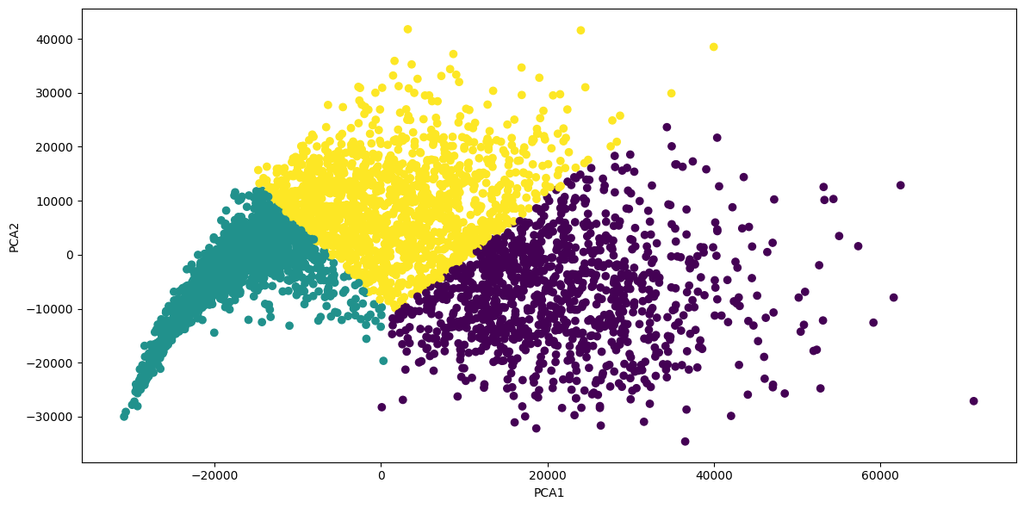

```python
# Векторын хэмжээ нь том тул ерөнхий баримжаа авах үүднээс хэмжээсийг бууруулан дүрсэлсэн нь
pca = PCA(n_components = 2)
pca_data = pca.fit_transform(encoded_abstracts['input_ids'])

num_clusters = 3
kmeans = KMeans(n_clusters = num_clusters)
kmeans.fit(pca_data)
cluster_labels = kmeans.labels_

fig, ax = plt.subplots(num = 1, clear = True, figsize = (12, 6))

ax.scatter(pca_data[:, 0], pca_data[:, 1], c = cluster_labels)
ax.set_xlabel("PCA1")
ax.set_ylabel("PCA2")

fig.tight_layout();
```

### 3.2 NER

Энэ хэсэгт мөн адил нэр үг олохын тул судалгааны өгүүлэл ашиглан сургасан модел ашигласан. Энэ [моделийг](https://huggingface.co/RJuro/SciNERTopic) нь [SciERC](https://nlp.cs.washington.edu/sciIE/) өгөгдөл ашиглан сургасан юм билээ.

```python
tokenizer = AutoTokenizer.from_pretrained("RJuro/SciNERTopic")
model_trf = AutoModelForTokenClassification.from_pretrained("RJuro/SciNERTopic")

nlp = pipeline("ner", model = model_trf, tokenizer = tokenizer, aggregation_strategy = 'average')
```

```python
result_dict = defaultdict(list)

def extract_ner_worker(abstract, lock):
    local_result_dict = defaultdict(list)
    result = nlp(abstract)
    for item in result:
        entity_group = item['entity_group']
        word = item['word']
        local_result_dict[entity_group].append(word)
    # Өгөгдлийн уралдаан үүсэхээс сэргийлэх
    with lock:
        for key, value in local_result_dict.items():
            result_dict[key].extend(value)
```

```python
"""
lock = threading.Lock()

with ThreadPoolExecutor(max_workers = 12) as executor, tqdm(total = len(abstracts)) as pbar:
    futures = [executor.submit(extract_ner_worker, abstract, lock) for abstract in abstracts]
    for future in as_completed(futures):
        pbar.update()

file_path = "paper_abstracts_ner_dict.pkl"

with open(file_path, "wb") as file:
    pickle.dump(result_dict, file)
"""

file_path = "paper_abstracts_ner_dict.pkl"

with open(file_path, "rb") as file:
    result_dict = pickle.load(file)
```

```python
print(result_dict.keys())
```

```
dict_keys(['OtherScientificTerm', 'Task', 'Generic', 'Material', 'Method', 'Metric'])
```

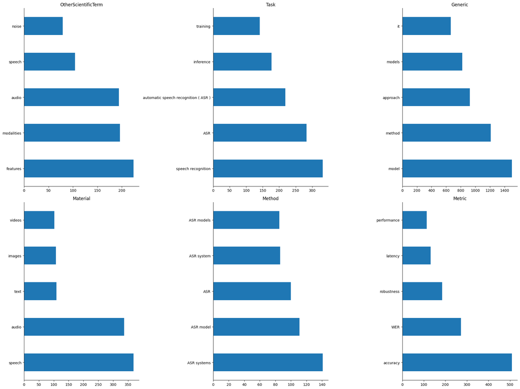

```python
fig, axs = plt.subplots(2, 3, num = 1, clear = True, figsize = (20, 15))

for i, category in enumerate(result_dict.keys()):
    category_counts = pd.Series(result_dict[category]).value_counts()[:5]

    row = i // 3
    col = i % 3
    ax = axs[row, col]

    category_counts.plot(kind = 'barh', ax = ax)

    ax.set_title(category)
    ax.spines[['top', 'right']].set_visible(False)

fig.tight_layout();
```

## 4. Co-authorship network

```python
sample_num = 5000
author_subset = author_pair_df.head(sample_num)

rn = nx.from_pandas_edgelist(author_subset, source = "Author1", target = "Author2")

print(rn)
```

```
Graph with 1515 nodes and 4791 edges
```

```python
# Source: https://plotly.com/python/network-graphs/
N = rn.number_of_nodes()
L = rn.number_of_edges()
Edges_name = [e for e in rn.edges()]
Edges = nx.convert_node_labels_to_integers(rn)
Edges = [e for e in Edges.edges()]

# Create an igraph graph
G = ig.Graph(Edges, directed=False)

# Use a 2D layout
layt = G.layout('fruchterman_reingold', dim = 2)

# Extract X, Y coordinates
Xn = [layt[k][0] for k in range(N)]
Yn = [layt[k][1] for k in range(N)]

Xe = []
Ye = []

for e in Edges:
    Xe += [layt[e[0]][0], layt[e[1]][0], None]
    Ye += [layt[e[0]][1], layt[e[1]][1], None]

labels = [e[0] for e in Edges_name]
group = np.repeat(1, 2000).tolist() + np.repeat(2, 2000).tolist() + np.repeat(3, 3000).tolist() + np.repeat(4, 1000).tolist() + np.repeat(5, 2000).tolist()

trace1 = go.Scatter(x = Xe, y = Ye, mode = 'lines',
                   line = dict(color = 'rgb(125,125,125)', width = 1), hoverinfo = 'none')

trace2 = go.Scatter(x = Xn, y = Yn, mode = 'markers', name = 'Researcher',
                   marker = dict(symbol = 'circle', size = 4, color = group, colorscale = 'Viridis',
                               line = dict(color = 'rgb(50,50,50)', width = 0.5)),
                   text = labels, hoverinfo = 'text')
```

```python
layout = go.Layout(
    title = f"Arxiv-с {search_term} түлхүүр үгийн дагуу хайлтаас илэрсэн өгүүллүүдийн хувьд тооцсон судлаачдын танилын сүлжээ. {sample_num} samples",
    autosize = True,
    width = 1200,
    height = 1000,
    showlegend = False,
    scene = dict(),
    margin = dict(t = 100),
    hovermode = 'closest',
    annotations = [
        dict(
            showarrow = False,
            text = "Гүйцэтгэсэн Э.Тэмүүжин (20B1NUM1970) Хэрэглээний математик 4-р түвшин",
            xref = 'paper',
            yref = 'paper',
            x = 0,
            y = 0,
            xanchor = 'left',
            yanchor = 'bottom',
            font = dict(size = 14)
        )
    ])

data = [trace1, trace2]
fig = go.Figure(data = data, layout = layout)
fig.show()
```

[interactive chart not shown]